# PLS - Agencias

Artículo 1 (versión 2)

Roberto Gil-Saura

2/4/2021

NOTA: Modelo completo, pero quitamos LOY3.

# 1 Consideraciones sobre la muestra

# 2 Modelización

Seguidamente mostramos el modelo de medida (outer model) y el modelo estructural (inner model), establecidos a partir de las hipótesis lanzadas.

El modelo de medida es el siguiente:

[interactive chart not shown]

Modelo de medida

El modelo estructural es el siguiente:

[interactive chart not shown]

Modelo estructural

## 2.1 Análisis de la fiabilidad

Para el modelo de medida se han considerado constructos composite, modo A. De este modo, el primer paso debe ser observar el resumen de los indicadores de fiabilidad, consistencia interna y validez.

```
             alpha    rhoC     AVE    rhoA
ICT        "0.951" "0.968" "0.911" "0.951"
VCC        "0.851" "0.910" "0.772" "0.857"
TRUST      "0.842" "0.905" "0.762" "0.848"
COMMITMENT "0.894" "0.926" "0.758" "0.899"
SOCSAT     "0.867" "0.937" "0.882" "0.869"
ECOSAT     "0.924" "0.964" "0.930" "0.924"
LOY        "0.839" "0.903" "0.756" "0.845"

Alpha, rhoC, and rhoA should exceed 0.7 while AVE should exceed 0.5
```

## 2.2 Validez convergente

### 2.2.1 AVE

Del mismo modo, para evaluar la *validez convergente* o grado con el que una medida correlaciona positivamente con medidas alternativas del mismo constructo, usamos el coeficiente *AVE (average variance extracted)* que también cumple con la expectativa de estar por encima de 0.5.

```
             alpha    rhoC     AVE    rhoA
ICT        "0.951" "0.968" "0.911" "0.951"
VCC        "0.851" "0.910" "0.772" "0.857"
TRUST      "0.842" "0.905" "0.762" "0.848"
COMMITMENT "0.894" "0.926" "0.758" "0.899"
SOCSAT     "0.867" "0.937" "0.882" "0.869"
ECOSAT     "0.924" "0.964" "0.930" "0.924"
LOY        "0.839" "0.903" "0.756" "0.845"

Alpha, rhoC, and rhoA should exceed 0.7 while AVE should exceed 0.5
```

Los indicadores son mostrados de forma conjunta en el siguiente gráfico.

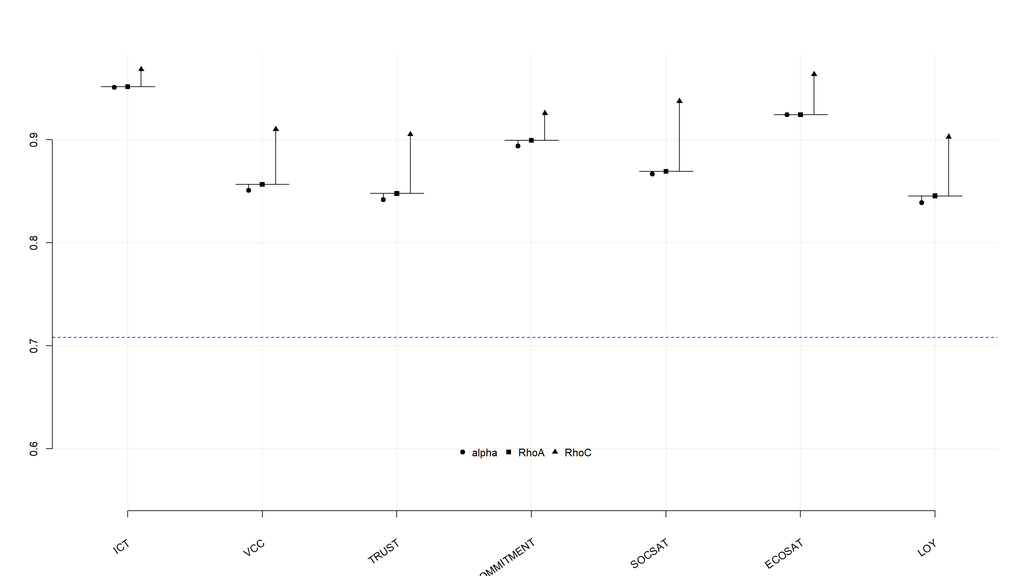

Tabla de fiabilidad

### 2.2.2 Análisis de las cargas

Por otro lado, es importante analizar también las cargas o *loadings*, indicadores de la fiabilidad del indicador en el constructo, y que deberían ser mayores de 0.7 para retener el indicador; para aquellas que están entre 0.4 y 0.7 debe ser analizado el comportamiento del constructo ante una eliminación del indicador con carga baja[^2].

```
              ICT   VCC TRUST COMMITMENT SOCSAT ECOSAT   LOY
ICT1        0.949 0.000 0.000      0.000  0.000  0.000 0.000
ICT2        0.970 0.000 0.000      0.000  0.000  0.000 0.000
ICT3        0.943 0.000 0.000      0.000  0.000  0.000 0.000
VCC1        0.000 0.909 0.000      0.000  0.000  0.000 0.000
VCC2        0.000 0.910 0.000      0.000  0.000  0.000 0.000
VCC4        0.000 0.814 0.000      0.000  0.000  0.000 0.000
TRUST1      0.000 0.000 0.937      0.000  0.000  0.000 0.000
TRUST2      0.000 0.000 0.823      0.000  0.000  0.000 0.000
TRUST3      0.000 0.000 0.854      0.000  0.000  0.000 0.000
COMMITMENT1 0.000 0.000 0.000      0.867  0.000  0.000 0.000
COMMITMENT2 0.000 0.000 0.000      0.894  0.000  0.000 0.000
COMMITMENT3 0.000 0.000 0.000      0.843  0.000  0.000 0.000
COMMITMENT4 0.000 0.000 0.000      0.877  0.000  0.000 0.000
SOCSAT2     0.000 0.000 0.000      0.000  0.935  0.000 0.000
SOCSAT3     0.000 0.000 0.000      0.000  0.943  0.000 0.000
ECOSAT1     0.000 0.000 0.000      0.000  0.000  0.964 0.000
ECOSAT2     0.000 0.000 0.000      0.000  0.000  0.964 0.000
LOY1        0.000 0.000 0.000      0.000  0.000  0.000 0.892
LOY2        0.000 0.000 0.000      0.000  0.000  0.000 0.840
LOY4        0.000 0.000 0.000      0.000  0.000  0.000 0.876
```

## 2.3 Validez discriminante

### 2.3.1 Cross-loadings

Para el análisis de la validez discriminante o capacidad de un constructo de ser realmente distinto a otros, utilizamos las denominadas *cross-loadings*, que miden esa capacidad del constructo. En la tabla adjunta se puede observar en cada indicador carga de forma superior en su variable latente, siendo el resto de cargas de menor intensidad.

```
              ICT   VCC TRUST COMMITMENT SOCSAT ECOSAT   LOY
ICT1        0.949 0.463 0.081      0.213  0.229  0.196 0.322
ICT2        0.970 0.454 0.123      0.241  0.214  0.188 0.311
ICT3        0.943 0.481 0.142      0.281  0.277  0.259 0.344
VCC1        0.449 0.909 0.445      0.553  0.448  0.605 0.649
VCC2        0.449 0.910 0.326      0.528  0.396  0.509 0.584
VCC4        0.387 0.814 0.354      0.517  0.445  0.399 0.549
TRUST1      0.102 0.375 0.937      0.545  0.587  0.486 0.487
TRUST2      0.115 0.454 0.823      0.497  0.466  0.563 0.474
TRUST3      0.101 0.292 0.854      0.527  0.495  0.361 0.425
COMMITMENT1 0.262 0.649 0.520      0.867  0.512  0.531 0.609
COMMITMENT2 0.270 0.640 0.521      0.894  0.523  0.529 0.649
COMMITMENT3 0.167 0.367 0.527      0.843  0.480  0.268 0.395
COMMITMENT4 0.181 0.417 0.520      0.877  0.512  0.320 0.475
SOCSAT2     0.201 0.435 0.575      0.523  0.935  0.561 0.628
SOCSAT3     0.270 0.483 0.541      0.569  0.943  0.638 0.727
ECOSAT1     0.213 0.550 0.515      0.449  0.617  0.964 0.624
ECOSAT2     0.222 0.566 0.528      0.485  0.616  0.964 0.623
LOY1        0.294 0.629 0.490      0.553  0.683  0.615 0.892
LOY2        0.298 0.565 0.420      0.502  0.520  0.550 0.840
LOY4        0.301 0.570 0.472      0.564  0.681  0.514 0.876
```

### 2.3.2 Fornell-Larcker

El criterio de Fornell-Larcker, compara la raíz cuadrado del *AVE* con la correlación de las variables latentes. La raíz cuadrada del AVE de cada constructo, debería ser más grande que la más alta correlación con cualquier otro constructo. Se puede observar en la tabla siguiente que el valor en la diagonal principal, es mayor que el resto de valores en la parte inferior de la matriz.

```
             ICT   VCC TRUST COMMITMENT SOCSAT ECOSAT   LOY
ICT        0.954     .     .          .      .      .     .
VCC        0.488 0.879     .          .      .      .     .
TRUST      0.121 0.429 0.873          .      .      .     .
COMMITMENT 0.257 0.607 0.599      0.870      .      .     .
SOCSAT     0.252 0.489 0.594      0.583  0.939      .     .
ECOSAT     0.226 0.578 0.541      0.484  0.639  0.964     .
LOY        0.342 0.678 0.531      0.620  0.723  0.647 0.870

FL Criteria table reports square root of AVE on the diagonal and construct correlations on the lower triangle.
```

### 2.3.3 HTMT

Por último el HTMT es un ratio que si es mayor que 0.90 indica una pérdida de validez discriminante.

```
             ICT   VCC TRUST COMMITMENT SOCSAT ECOSAT LOY
ICT            .     .     .          .      .      .   .
VCC        0.542     .     .          .      .      .   .
TRUST      0.136 0.504     .          .      .      .   .
COMMITMENT 0.273 0.683 0.692          .      .      .   .
SOCSAT     0.276 0.570 0.694      0.660      .      .   .
ECOSAT     0.240 0.648 0.612      0.520  0.713      .   .
LOY        0.383 0.798 0.630      0.706  0.845  0.731   .
```

## 2.4 Análisis del modelo estructural

- R<sup>2</sup>, coeficiente de determinación y/o % de varianza explicada
- f<sup>2</sup> y q<sup>2</sup> efecto tamaño
- Q<sup>2</sup>, relevancia predictiva

### 2.4.1 Colinealidad

Colinealidad, estudiada con los inner VIF value (inverso de la tolerancia). Todos los valores deben ser menores a 0.20 en tolerancia, lo que implica ser menores a 5 en VIF. Los valores se dan para cada constructo.

#### 2.4.1.1 vif items

```
ICT :
 ICT1  ICT2  ICT3
5.463 7.838 4.420

VCC :
 VCC1  VCC2  VCC4
2.851 2.964 1.619

TRUST :
TRUST1 TRUST2 TRUST3
 3.427  1.825  2.452

COMMITMENT :
COMMITMENT1 COMMITMENT2 COMMITMENT3 COMMITMENT4
      2.966       3.256       3.379       3.742

SOCSAT :
SOCSAT2 SOCSAT3
  2.406   2.406

ECOSAT :
ECOSAT1 ECOSAT2
  3.819   3.819

LOY :
 LOY1  LOY2  LOY4
2.168 1.734 2.220
```

#### 2.4.1.2 vif antecedents

```
VCC :
ICT
  .

TRUST :
VCC
  .

COMMITMENT :
  VCC TRUST
1.226 1.226

SOCSAT :
     TRUST COMMITMENT
      1.56       1.56

ECOSAT :
SOCSAT
     .

LOY :
ECOSAT
     .
```

#### 2.4.1.3 Paths

```
             VCC TRUST COMMITMENT SOCSAT ECOSAT   LOY
R^2        0.239 0.184      0.509  0.433  0.409 0.418
AdjR^2     0.236 0.181      0.505  0.428  0.406 0.416
ICT        0.488     .          .      .      .     .
VCC            . 0.429      0.429      .      .     .
TRUST          .     .      0.415  0.381      .     .
COMMITMENT     .     .          .  0.354      .     .
SOCSAT         .     .          .      .  0.639     .
ECOSAT         .     .          .      .      . 0.647
```

### 2.4.2 R<sup>2</sup>

Buscar R<sup>2</sup> mayores de 0.7, aunque valores alrededor de 0.25 sean aceptados según ámbitos; (sustancial mayor que 0.75, moderado alrededor de 0.5 y débil, 0.25). Usar R<sup>2</sup><sub>adj</sub> para comparar modelos con diferente número de constructos y/u observaciones.

```
             VCC     TRUST COMMITMENT    SOCSAT    ECOSAT       LOY
Rsq    0.2385101 0.1841676  0.5089685 0.4325955 0.4087246 0.4183867
AdjRsq 0.2355121 0.1809557  0.5050868 0.4281101 0.4063967 0.4160969
```

### 2.4.3 f<sup>2</sup> - effect sizes

El f<sup>2</sup> permite evaluar la contribución de cada constructo exógeno a la R<sup>2</sup> de un constructo endógeno. Los valores de 0.02, 0.15 y 0.35 indican un efecto pequeño, mediano o grande sobre el constructo endógeno.

```
             ICT   VCC TRUST COMMITMENT SOCSAT ECOSAT   LOY
ICT        0.000 0.313 0.000      0.000  0.000  0.000 0.000
VCC        0.000 0.000 0.226      0.305  0.000  0.000 0.000
TRUST      0.000 0.000 0.000      0.268  0.163  0.000 0.000
COMMITMENT 0.000 0.000 0.000      0.000  0.141  0.000 0.000
SOCSAT     0.000 0.000 0.000      0.000  0.000  0.691 0.000
ECOSAT     0.000 0.000 0.000      0.000  0.000  0.000 0.719
LOY        0.000 0.000 0.000      0.000  0.000  0.000 0.000
```

### 2.4.4 Efectos

#### 2.4.4.1 Totales

```
             ICT   VCC TRUST COMMITMENT SOCSAT ECOSAT   LOY
ICT        0.000 0.488 0.210      0.296  0.185  0.118 0.076
VCC        0.000 0.000 0.429      0.607  0.379  0.242 0.157
TRUST      0.000 0.000 0.000      0.415  0.528  0.338 0.218
COMMITMENT 0.000 0.000 0.000      0.000  0.354  0.226 0.146
SOCSAT     0.000 0.000 0.000      0.000  0.000  0.639 0.414
ECOSAT     0.000 0.000 0.000      0.000  0.000  0.000 0.647
LOY        0.000 0.000 0.000      0.000  0.000  0.000 0.000
```

#### 2.4.4.2 Indirectos

```
             ICT   VCC TRUST COMMITMENT SOCSAT ECOSAT   LOY
ICT        0.000 0.000 0.210      0.296  0.185  0.118 0.076
VCC        0.000 0.000 0.000      0.178  0.379  0.242 0.157
TRUST      0.000 0.000 0.000      0.000  0.147  0.338 0.218
COMMITMENT 0.000 0.000 0.000      0.000  0.000  0.226 0.146
SOCSAT     0.000 0.000 0.000      0.000  0.000  0.000 0.414
ECOSAT     0.000 0.000 0.000      0.000  0.000  0.000 0.000
LOY        0.000 0.000 0.000      0.000  0.000  0.000 0.000
```

### 2.4.5 it_criteria

```
        VCC   TRUST COMMITMENT   SOCSAT   ECOSAT      LOY
AIC -66.756 -49.110   -177.081 -140.073 -131.523 -135.741
BIC -59.666 -42.019   -166.446 -129.437 -124.433 -128.651
```

# 3 Modelización con bootstrapping

*Bootstrapping* para calcular la significatividad de los paths estimados. Habitualmente se trabaja con un 5% (t > 1.96) lo que implica significatividad al 95%. Podemos cambiar al 10 o al 1 según ámbito. Usar doble *bootstrapping* si hay menos de 4 constructos.

## 3.1 Structural paths

```
                       Original Est. Bootstrap Mean Bootstrap SD T Stat. 2.5% CI 97.5% CI
ICT  ->  VCC                   0.488          0.489        0.055   8.894   0.375    0.591
VCC  ->  TRUST                 0.429          0.430        0.056   7.721   0.313    0.533
VCC  ->  COMMITMENT            0.429          0.429        0.048   8.990   0.331    0.518
TRUST  ->  COMMITMENT          0.415          0.414        0.057   7.331   0.304    0.524
TRUST  ->  SOCSAT              0.381          0.380        0.071   5.365   0.238    0.518
COMMITMENT  ->  SOCSAT         0.354          0.353        0.075   4.725   0.201    0.499
SOCSAT  ->  ECOSAT             0.639          0.640        0.038  16.949   0.562    0.710
ECOSAT  ->  LOY                0.647          0.649        0.046  14.123   0.553    0.731
```

## 3.2 Bootstrapped weights

```
                            Original Est. Bootstrap Mean Bootstrap SD T Stat. 2.5% CI 97.5% CI
ICT1  ->  ICT                       0.347          0.347        0.014  25.598   0.321    0.374
ICT2  ->  ICT                       0.340          0.340        0.013  27.116   0.314    0.362
ICT3  ->  ICT                       0.361          0.361        0.020  17.664   0.326    0.407
VCC1  ->  VCC                       0.408          0.408        0.017  23.634   0.377    0.445
VCC2  ->  VCC                       0.371          0.371        0.014  26.255   0.344    0.400
VCC4  ->  VCC                       0.358          0.358        0.021  17.285   0.317    0.397
TRUST1  ->  TRUST                   0.409          0.408        0.016  26.266   0.378    0.440
TRUST2  ->  TRUST                   0.376          0.380        0.025  14.920   0.333    0.434
TRUST3  ->  TRUST                   0.360          0.358        0.019  18.951   0.317    0.393
COMMITMENT1  ->  COMMITMENT         0.310          0.310        0.016  19.632   0.282    0.344
COMMITMENT2  ->  COMMITMENT         0.311          0.311        0.015  21.127   0.284    0.342
COMMITMENT3  ->  COMMITMENT         0.256          0.257        0.013  19.299   0.230    0.283
COMMITMENT4  ->  COMMITMENT         0.271          0.270        0.013  20.408   0.243    0.295
SOCSAT2  ->  SOCSAT                 0.515          0.514        0.013  38.857   0.488    0.540
SOCSAT3  ->  SOCSAT                 0.550          0.551        0.015  37.609   0.525    0.581
ECOSAT1  ->  ECOSAT                 0.519          0.519        0.015  34.538   0.493    0.551
ECOSAT2  ->  ECOSAT                 0.518          0.518        0.011  46.783   0.498    0.541
LOY1  ->  LOY                       0.421          0.421        0.022  19.272   0.382    0.466
LOY2  ->  LOY                       0.376          0.376        0.022  16.753   0.333    0.422
LOY4  ->  LOY                       0.352          0.351        0.022  16.161   0.307    0.393
```

## 3.3 Bootstrapped loadings

```
                            Original Est. Bootstrap Mean Bootstrap SD T Stat. 2.5% CI 97.5% CI
ICT1  ->  ICT                       0.949          0.949        0.015  64.631   0.916    0.973
ICT2  ->  ICT                       0.970          0.970        0.008 124.170   0.952    0.982
ICT3  ->  ICT                       0.943          0.944        0.010  92.550   0.922    0.962
VCC1  ->  VCC                       0.909          0.909        0.011  79.371   0.884    0.929
VCC2  ->  VCC                       0.910          0.909        0.018  50.078   0.869    0.939
VCC4  ->  VCC                       0.814          0.813        0.028  28.572   0.752    0.863
TRUST1  ->  TRUST                   0.937          0.937        0.011  87.167   0.913    0.954
TRUST2  ->  TRUST                   0.823          0.825        0.023  35.352   0.777    0.867
TRUST3  ->  TRUST                   0.854          0.850        0.029  29.873   0.787    0.898
COMMITMENT1  ->  COMMITMENT         0.867          0.867        0.021  42.062   0.823    0.903
COMMITMENT2  ->  COMMITMENT         0.894          0.894        0.015  57.922   0.860    0.921
COMMITMENT3  ->  COMMITMENT         0.843          0.842        0.025  33.101   0.786    0.888
COMMITMENT4  ->  COMMITMENT         0.877          0.876        0.022  40.467   0.828    0.913
SOCSAT2  ->  SOCSAT                 0.935          0.934        0.011  85.756   0.911    0.954
SOCSAT3  ->  SOCSAT                 0.943          0.943        0.009 108.289   0.925    0.958
ECOSAT1  ->  ECOSAT                 0.964          0.964        0.009 111.884   0.946    0.979
ECOSAT2  ->  ECOSAT                 0.964          0.964        0.010  92.624   0.940    0.980
LOY1  ->  LOY                       0.892          0.892        0.013  69.919   0.866    0.916
LOY2  ->  LOY                       0.840          0.839        0.031  26.815   0.770    0.892
LOY4  ->  LOY                       0.876          0.876        0.020  43.466   0.832    0.911
```

## 3.4 Bootstrapped HTMT

```
                       Original Est. Bootstrap Mean Bootstrap SD T Stat. 2.5% CI 97.5% CI
ICT  ->  VCC                   0.542          0.541        0.060   9.047   0.417    0.654
ICT  ->  TRUST                 0.136          0.142        0.066   2.049   0.038    0.283
ICT  ->  COMMITMENT            0.273          0.273        0.066   4.149   0.143    0.399
ICT  ->  SOCSAT                0.276          0.275        0.075   3.681   0.119    0.417
ICT  ->  ECOSAT                0.240          0.239        0.069   3.476   0.102    0.371
ICT  ->  LOY                   0.383          0.382        0.075   5.130   0.229    0.520
VCC  ->  TRUST                 0.504          0.503        0.065   7.724   0.366    0.623
VCC  ->  COMMITMENT            0.683          0.682        0.039  17.419   0.601    0.755
VCC  ->  SOCSAT                0.570          0.569        0.064   8.866   0.433    0.683
VCC  ->  ECOSAT                0.648          0.647        0.047  13.779   0.548    0.734
VCC  ->  LOY                   0.798          0.799        0.044  18.221   0.708    0.880
TRUST  ->  COMMITMENT          0.692          0.690        0.053  12.984   0.581    0.789
TRUST  ->  SOCSAT              0.694          0.691        0.059  11.712   0.570    0.800
TRUST  ->  ECOSAT              0.612          0.611        0.054  11.347   0.502    0.709
TRUST  ->  LOY                 0.630          0.629        0.070   9.064   0.487    0.756
COMMITMENT  ->  SOCSAT         0.660          0.657        0.062  10.666   0.530    0.769
COMMITMENT  ->  ECOSAT         0.520          0.520        0.058   8.979   0.401    0.630
COMMITMENT  ->  LOY            0.706          0.705        0.049  14.295   0.602    0.795
SOCSAT  ->  ECOSAT             0.713          0.713        0.040  17.734   0.632    0.785
SOCSAT  ->  LOY                0.845          0.843        0.046  18.235   0.742    0.923
ECOSAT  ->  LOY                0.731          0.732        0.052  14.003   0.622    0.827
```

## 3.5 Total effects (paths)

```
                       Original Est. Bootstrap Mean Bootstrap SD T Stat. 2.5% CI 97.5% CI
ICT  ->  VCC                   0.488          0.489        0.055   8.894   0.375    0.591
ICT  ->  TRUST                 0.210          0.211        0.038   5.556   0.136    0.285
ICT  ->  COMMITMENT            0.296          0.297        0.040   7.470   0.218    0.373
ICT  ->  SOCSAT                0.185          0.186        0.033   5.683   0.124    0.252
ICT  ->  ECOSAT                0.118          0.119        0.025   4.823   0.075    0.171
ICT  ->  LOY                   0.076          0.078        0.018   4.138   0.046    0.118
VCC  ->  TRUST                 0.429          0.430        0.056   7.721   0.313    0.533
VCC  ->  COMMITMENT            0.607          0.608        0.036  16.874   0.533    0.674
VCC  ->  SOCSAT                0.379          0.380        0.047   8.123   0.286    0.469
VCC  ->  ECOSAT                0.242          0.244        0.039   6.228   0.169    0.321
VCC  ->  LOY                   0.157          0.159        0.032   4.905   0.099    0.224
TRUST  ->  COMMITMENT          0.415          0.414        0.057   7.331   0.304    0.524
TRUST  ->  SOCSAT              0.528          0.526        0.060   8.877   0.407    0.640
TRUST  ->  ECOSAT              0.338          0.337        0.046   7.394   0.248    0.426
TRUST  ->  LOY                 0.218          0.219        0.037   5.846   0.151    0.297
COMMITMENT  ->  SOCSAT         0.354          0.353        0.075   4.725   0.201    0.499
COMMITMENT  ->  ECOSAT         0.226          0.227        0.052   4.349   0.125    0.328
COMMITMENT  ->  LOY            0.146          0.148        0.038   3.865   0.077    0.225
SOCSAT  ->  ECOSAT             0.639          0.640        0.038  16.949   0.562    0.710
SOCSAT  ->  LOY                0.414          0.416        0.047   8.883   0.322    0.504
ECOSAT  ->  LOY                0.647          0.649        0.046  14.123   0.553    0.731
```

## 3.6 Plot model

[interactive chart not shown]

Modelo con bootstrapping

# 4 Predicción (seminr)

RMSE: root mean squared residuals MAE: mean absolute residuals

```
PLS in-sample metrics:
      VCC1  VCC2  VCC4 TRUST1 TRUST2 TRUST3 COMMITMENT1 COMMITMENT2 COMMITMENT3 COMMITMENT4 SOCSAT2 SOCSAT3 ECOSAT1 ECOSAT2  LOY1  LOY2  LOY4
RMSE 1.659 1.429 1.366  0.764  1.166  0.750       1.029       0.831       0.864       0.902   0.733   0.897   1.197   1.189 0.905 1.294 0.996
MAD  1.384 1.156 1.092  0.575  0.946  0.576       0.806       0.675       0.630       0.677   0.556   0.679   0.943   0.955 0.699 1.042 0.731

PLS out-of-sample metrics:
      VCC1  VCC2  VCC4 TRUST1 TRUST2 TRUST3 COMMITMENT1 COMMITMENT2 COMMITMENT3 COMMITMENT4 SOCSAT2 SOCSAT3 ECOSAT1 ECOSAT2  LOY1  LOY2  LOY4
RMSE 1.669 1.441 1.381  0.770  1.173  0.756       1.050       0.843       0.875       0.914   0.742   0.908   1.205   1.199 0.915 1.311 1.009
MAD  1.393 1.165 1.104  0.581  0.951  0.583       0.821       0.683       0.638       0.686   0.560   0.685   0.947   0.962 0.706 1.055 0.741

LM in-sample metrics:
      VCC1  VCC2  VCC4 TRUST1 TRUST2 TRUST3 COMMITMENT1 COMMITMENT2 COMMITMENT3 COMMITMENT4 SOCSAT2 SOCSAT3 ECOSAT1 ECOSAT2  LOY1  LOY2  LOY4
RMSE 1.089 1.084 1.089  0.593  0.897  0.597       0.933       0.769       0.772       0.811   0.589   0.662   0.967   0.953 0.691 1.100 0.733
MAD  0.857 0.871 0.886  0.464  0.704  0.486       0.732       0.608       0.563       0.586   0.450   0.508   0.763   0.737 0.529 0.887 0.558

LM out-of-sample metrics:
      VCC1  VCC2  VCC4 TRUST1 TRUST2 TRUST3 COMMITMENT1 COMMITMENT2 COMMITMENT3 COMMITMENT4 SOCSAT2 SOCSAT3 ECOSAT1 ECOSAT2  LOY1  LOY2  LOY4
RMSE 1.204 1.225 1.207  0.657  1.045  0.657       1.051       0.845       0.878       0.913   0.658   0.775   1.090   1.059 0.790 1.245 0.851
MAD  0.946 0.963 0.966  0.509  0.789  0.526       0.809       0.663       0.627       0.640   0.497   0.573   0.848   0.817 0.587 0.984 0.626
```

# 5 Relevancia predictiva (matrixpls)

(con matrixpls -Aldás y Uriel, 2017-)

```
 matrixpls parameter estimates
                             Est.
ICT~VCC                 0.4883856
VCC~TRUST               0.1039055
VCC~COMMITMENT          0.5487876
TRUST~COMMITMENT        0.3458385
TRUST~ECOSAT            0.2146789
COMMITMENT~ECOSAT       0.1958393
TRUST~SOCSAT            0.2539035
COMMITMENT~SOCSAT       0.4574506
ECOSAT~LOY              0.6443570
SOCSAT~LOY              0.7268156
ICT=~ICT1               0.9493510
ICT=~ICT2               0.9699960
ICT=~ICT3               0.9434736
VCC=~VCC1               0.9077209
VCC=~VCC2               0.9115590
VCC=~VCC4               0.8131066
TRUST=~TRUST1           0.9338387
TRUST=~TRUST2           0.8366640
TRUST=~TRUST3           0.8425088
COMMITMENT=~COMMITMENT1 0.8724395
COMMITMENT=~COMMITMENT2 0.8978690
COMMITMENT=~COMMITMENT3 0.8364320
COMMITMENT=~COMMITMENT4 0.8720864
ECOSAT=~ECOSAT1         0.9631817
ECOSAT=~ECOSAT2         0.9650924
SOCSAT=~SOCSAT2         0.9348181
SOCSAT=~SOCSAT3         0.9435707
LOY=~LOY1               0.8934146
LOY=~LOY2               0.8255714
LOY=~LOY4               0.8885357

 matrixpls weights
                ICT1      ICT2      ICT3      VCC1      VCC2      VCC4    TRUST1    TRUST2    TRUST3 COMMITMENT1 COMMITMENT2 COMMITMENT3 COMMITMENT4   ECOSAT1   ECOSAT2   SOCSAT2   SOCSAT3      LOY1     LOY2      LOY4
ICT        0.3469375 0.3404026 0.3608424 0.0000000 0.0000000 0.0000000 0.0000000 0.0000000 0.0000000    0.000000   0.0000000     0.00000   0.0000000 0.0000000 0.0000000 0.0000000 0.0000000 0.0000000 0.000000 0.0000000
VCC        0.0000000 0.0000000 0.0000000 0.3998498 0.3806655 0.3567169 0.0000000 0.0000000 0.0000000    0.000000   0.0000000     0.00000   0.0000000 0.0000000 0.0000000 0.0000000 0.0000000 0.0000000 0.000000 0.0000000
TRUST      0.0000000 0.0000000 0.0000000 0.0000000 0.0000000 0.0000000 0.4014986 0.4045287 0.3401869    0.000000   0.0000000     0.00000   0.0000000 0.0000000 0.0000000 0.0000000 0.0000000 0.0000000 0.000000 0.0000000
COMMITMENT 0.0000000 0.0000000 0.0000000 0.0000000 0.0000000 0.0000000 0.0000000 0.0000000 0.0000000    0.319258   0.3188659     0.24676   0.2623237 0.0000000 0.0000000 0.0000000 0.0000000 0.0000000 0.000000 0.0000000
ECOSAT     0.0000000 0.0000000 0.0000000 0.0000000 0.0000000 0.0000000 0.0000000 0.0000000 0.0000000    0.000000   0.0000000     0.00000   0.0000000 0.5118094 0.5253741 0.0000000 0.0000000 0.0000000 0.000000 0.0000000
```

[output cut: 94 more lines]

```
ICT        0.0000000 0.0000000 0.0000000  0.0000000 0.0000000 0.0000000 0.0000000
VCC        0.5419678 0.0000000 0.0000000  0.0000000 0.0000000 0.0000000 0.0000000
TRUST      0.1355450 0.5042157 0.0000000  0.0000000 0.0000000 0.0000000 0.0000000
COMMITMENT 0.2734956 0.6828036 0.6921706  0.0000000 0.0000000 0.0000000 0.0000000
ECOSAT     0.2397299 0.6477240 0.6116554  0.5203428 0.0000000 0.0000000 0.0000000
SOCSAT     0.2756519 0.5695778 0.6942821  0.6600612 0.7129264 0.0000000 0.0000000
LOY        0.3826186 0.7984864 0.6302629  0.7061534 0.7308363 0.8445077 0.0000000

 Composite equilevance indices

 CEI individual
       ICT        VCC      TRUST COMMITMENT     ECOSAT     SOCSAT        LOY
 0.9999845  0.9997960  0.9994656  0.9987104  0.9999935  0.9999187  0.9994065

 CEI total: 0.9987104
```

```
 Q2 predictive relevance statistics

 Overall Q2
0.2341542
 Block Q2
       ICT        VCC      TRUST COMMITMENT     ECOSAT     SOCSAT        LOY
0.17056613 0.18681587 0.15371367 0.04276342 0.43473008 0.36707794 0.56055796

 Indicator Q2
     TRUST1      TRUST2      TRUST3 COMMITMENT1 COMMITMENT2 COMMITMENT3 COMMITMENT4        VCC1        VCC2        VCC4     ECOSAT1     ECOSAT2     SOCSAT2     SOCSAT3        LOY1        LOY2        LOY4        ICT1        ICT2        ICT3
 -0.6867281   0.5265296  -1.9044348   0.3397442   0.2071361  -0.7985971  -0.5609816   0.1374182   0.2126363   0.2698473   0.4344558   0.4350189  -0.1015835   0.5983180   0.7069671   0.4419235   0.7440816   0.1752786   0.1626654   0.1745154
```

# 6 Potencia (matrixpls)

```
     Multiple regression power calculation

              u = 4
              v = 251
             f2 = 0.15
      sig.level = 0.05
          power = 0.999663
```

```
     Multiple regression power calculation

              u = 4
              v = 79.44992
             f2 = 0.15
      sig.level = 0.05
          power = 0.8
```

[^1]: En https://forum.smartpls.com/viewtopic.php?f=5&t=3805 hay una “discusión en torno al”greater than 0.9" de Primer PLS … de Hair; lo solventa un investigador / desarrollador de SmartPLS: https://www.researchgate.net/profile/Jan_Michael_Becker
[^2]: En nuestro caso al proceder con la eliminación de aquellas cargas menores de 0.7 no mejoraba significativamente el modelo